# Capstone Project: Cyclistic Bike-Share

Andres Guzman Rodriguez

2024-02-26

### Scenario

You are a junior data analyst working on the marketing analyst team at Cyclistic, a bike-share company in Chicago. The director of marketing believes the company’s future success depends on maximizing the number of annual memberships. Therefore, your team wants to understand how casual riders and annual members use Cyclistic bikes differently. From these insights, your team will design a new marketing strategy to convert casual riders into annual members. But first, Cyclistic executives must approve your recommendations, so they must be backed up with compelling data insights and professional data visualizations.

### About the company

Cyclistic Bike-Share is a fictional Chicago based bike-share program that features more than 5,800 bicycles and 600 docking stations. This program offers reclining bicycles, hand tricycles, and cargo bikes. Cyclistic offers two types of memberships, casual and members. Casual riders are the ones who purchase a single-ride pass or a full-day pass, while the members are the riders who purchase an annual membership.

### 1. Ask

The guiding questions are the following:

1. How do annual members and casual riders use Cyclistic bikes differently?
2. How do annual members and casual riders use Cyclistic bikes differently?
3. Why would casual riders buy Cyclistic annual memberships?
4. How can Cyclistic use digital media to influence casual riders to become members?

#### Business Task

Understand how casual riders and annual members use Cyclistic bikes differently. From this insights, the marketing team will design a marketing strategy to convert casual riders to members.

#### Stakeholders

- **Cyclistic executive team**
- **Director of marketing**
- **Cyclistic marketing analytics team**

### 2. Prepare

The last 12 months of Cyclistic’s trip data (From February 2023 to January 2024) are made available in separate .csv files at this [site](https://divvy-tripdata.s3.amazonaws.com/index.html). The historic data for Cyclistic’s trip data is made available by Motivate International Inc. under this [license](https://divvybikes.com/data-license-agreement).

##### Loading packages and setting up the R environment

```r
library(tidyverse)
library(readr)
library(skimr)
library(tidyr)
library(janitor)
```

```r
library(dplyr)
library(lubridate)
library(ggplot2)
```

##### Loading the data

To load the data, we will use the read_csv function included in the **readr** package. We will load the historic data from February 2023 to January 2024.

```r
feb23 <- read_csv("C:/Users/Andre/Documents/Capstone/202302-divvy-tripdata.csv",show_col_types = FALSE)
mar23 <- read_csv("C:/Users/Andre/Documents/Capstone/202303-divvy-tripdata.csv",show_col_types = FALSE)
apr23 <- read_csv("C:/Users/Andre/Documents/Capstone/202304-divvy-tripdata.csv",show_col_types = FALSE)
may23 <- read_csv("C:/Users/Andre/Documents/Capstone/202305-divvy-tripdata.csv",show_col_types = FALSE)
jun23 <- read_csv("C:/Users/Andre/Documents/Capstone/202306-divvy-tripdata.csv",show_col_types = FALSE)
jul23 <- read_csv("C:/Users/Andre/Documents/Capstone/202307-divvy-tripdata.csv",show_col_types = FALSE)
aug23 <- read_csv("C:/Users/Andre/Documents/Capstone/202308-divvy-tripdata.csv",show_col_types = FALSE)
sep23 <- read_csv("C:/Users/Andre/Documents/Capstone/202309-divvy-tripdata.csv",show_col_types = FALSE)
oct23 <- read_csv("C:/Users/Andre/Documents/Capstone/202310-divvy-tripdata.csv",show_col_types = FALSE)
nov23 <-read_csv("C:/Users/Andre/Documents/Capstone/202311-divvy-tripdata.csv",show_col_types = FALSE)
dec23 <- read_csv("C:/Users/Andre/Documents/Capstone/202312-divvy-tripdata.csv",show_col_types = FALSE)
jan24 <- read_csv("C:/Users/Andre/Documents/Capstone/202401-divvy-tripdata.csv",show_col_types = FALSE)
```

##### Reliable, Original, Comprehensive, Current, Cited (ROCCC)

To measure the reliability of a data set we use the process **ROCCC*, which consists of:

- **Reliable:** Data sources are reliable, accurate, complete and unbiased information.
- **Original:** Data from first, second, or third party source. In this case, the data was made available by Motivate International Inc, which is a first party source.
- **Comprehensive:** The data set contains all the critical information to answer the question or find the solution.
- **Current:** We will use the historic data trips from the last 12 months, from February 2023 to January 2024.
- **Cited:** The data is under a *data licence agreement* which grants us a non-exclusive, royalty-free, limited, perpetual licence to access, reproduce, analyze, copy, modify, and distribution of the data.

##### Joining the data

To join all twelve months of trip data, we will use the *rbind()* function

```r
cyclistic_trips <- rbind(feb23,mar23,apr23,may23,jun23,jul23,aug23,sep23,oct23,nov23,dec23,jan24)
```

We get a data frame with 5,674,449 rows.

Now, we want to the structure of the data set, in this case, we want to know the name of the columns and the total missing values.

```r
colnames(cyclistic_trips)
```

```
##  [1] "ride_id"            "rideable_type"      "started_at"
##  [4] "ended_at"           "start_station_name" "start_station_id"
##  [7] "end_station_name"   "end_station_id"     "start_lat"
## [10] "start_lng"          "end_lat"            "end_lng"
## [13] "member_casual"
```

To narrow down the information we are going to use, we will select the columns that are important to our analysis, which are the following: -**rideable_type**: Type of bicycle that was used on a trip. -**started_at**: Starting time of the trip. -**ended_at**: End time of the trip. -**start_station_name**: Name of the starting station. -**start_station_id**: ID of the starting station. -**end_station_name**: Name of the ending station. -**end_station_id**: ID of the ending station. -**member_casual**: Type of member that used Cyclistic, casual or member.

Now, we create the data frame with the columns we will use.

```r
complete_trips <- cyclistic_trips %>%
  select(rideable_type,started_at,ended_at,start_station_name,start_station_id,end_station_name,end_station_id,member_casual)
```

We check the columns in the new data frame.

```r
colnames(complete_trips)
```

```
## [1] "rideable_type"      "started_at"         "ended_at"
## [4] "start_station_name" "start_station_id"   "end_station_name"
## [7] "end_station_id"     "member_casual"
```

We look how many missing values are there in the new data set.

```r
sum(is.na(complete_trips))
```

```
## [1] 3580815
```

```r
colSums(is.na(complete_trips))
```

```
##      rideable_type         started_at           ended_at start_station_name
##                  0                  0                  0             868160
##   start_station_id   end_station_name     end_station_id      member_casual
##             868292             922111             922252                  0
```

There are 3,580,815 missing values across all columns, the majority of them are in the start and end station name and, in the start and end station ID. These values won’t affect the analysis, so we will keep them.

### 3. Proccess

We need to add the columns that store the day, month, year, and date of each trip. This will be useful for knowing which are the busiest days and the busiest months.

```r
complete_trips$date <- as.Date(complete_trips$started_at)
complete_trips$day <- format(as.Date(complete_trips$date),"%d")
complete_trips$month <- format(as.Date(complete_trips$date),"%m")
complete_trips$year <- format(as.Date(complete_trips$date),"%Y")
complete_trips$day_of_week <- format(as.Date(complete_trips$date),"%A")
#We also create the column ride length, which is the total time of the ride.
complete_trips$ride_length <- difftime(complete_trips$ended_at,complete_trips$started_at, units="mins")
complete_trips$ride_length <- round(complete_trips$ride_length, digits = 2)
glimpse(complete_trips)
```

```
## Rows: 5,674,449
## Columns: 14
## $ rideable_type      <chr> "classic_bike", "electric_bike", "classic_bike", "e…
## $ started_at         <dttm> 2023-02-14 11:59:42, 2023-02-15 13:53:48, 2023-02-…
## $ ended_at           <dttm> 2023-02-14 12:13:38, 2023-02-15 13:59:08, 2023-02-…
## $ start_station_name <chr> "Southport Ave & Clybourn Ave", "Clarendon Ave & Go…
## $ start_station_id   <chr> "TA1309000030", "13379", "TA1309000030", "TA1309000…
## $ end_station_name   <chr> "Clark St & Schiller St", "Sheridan Rd & Lawrence A…
## $ end_station_id     <chr> "TA1309000024", "TA1309000041", "13156", "TA1309000…
## $ member_casual      <chr> "casual", "casual", "member", "member", "member", "…
## $ date               <date> 2023-02-14, 2023-02-15, 2023-02-19, 2023-02-26, 20…
## $ day                <chr> "14", "15", "19", "26", "20", "24", "28", "27", "08…
## $ month              <chr> "02", "02", "02", "02", "02", "02", "02", "02", "02…
## $ year               <chr> "2023", "2023", "2023", "2023", "2023", "2023", "20…
## $ day_of_week        <chr> "martes", "miércoles", "domingo", "domingo", "lunes…
## $ ride_length        <drtn> 13.93 mins, 5.33 mins, 24.07 mins, 27.83 mins, 10.…
```

We remove the *ride_length* entries where the values are below zero.

```r
complete_trips_2 <- na.omit(cyclistic_trips)
complete_trips_2 <- complete_trips[!(complete_trips$ride_length<0),]
```

Mutating *ride_length* to a numeric value so we can run the calculations in the *analysis* process.

```r
complete_trips_2$ride_length <- as.numeric(complete_trips_2$ride_length)
is.numeric(complete_trips_2$ride_length)
```

```
## [1] TRUE
```

### 4. Analyze

Now, we will run some calculations to get a better sense of the data. The calculations will be:

- Average ride length
- Maximum ride length
- Total members and casual riders and the percentage of them.
- Average and maximum length per member.
- Number of rides for user by day of the week.
- Average ride length by day of the week.

```r
#Average ride length
 avrg_ride <- mean(complete_trips_2$ride_length)
#Maximum ride length
max(complete_trips_2$ride_length)
```

```
## [1] 98489.07
```

The maximum ride length is over 68 days, so we will put a limit in ride length, which will be 23 hours that equals 1380 minutes.

```r
complete_trips_2 <- complete_trips_2[!(complete_trips_2$ride_length>1380),]
#Maximum ride length
max(complete_trips_2$ride_length)
```

```
## [1] 1379.93
```

```r
#Percentage of members
members <- complete_trips_2 %>%
  group_by(member_casual) %>%
  summarize(Num_members= n(), Percentage= n()/sum(nrow(complete_trips_2))*100)
print(members)
```

```
## # A tibble: 2 × 3
##   member_casual Num_members Percentage
##   <chr>               <int>      <dbl>
## 1 casual            2038076       36.0
## 2 member            3629294       64.0
```

Average length per member:

```r
summary_members <- complete_trips_2 %>%
  group_by(member_casual) %>%
  summarize(average_length=mean(ride_length),max_length = max(ride_length))
print(summary_members)
```

```
## # A tibble: 2 × 3
##   member_casual average_length max_length
##   <chr>                  <dbl>      <dbl>
## 1 casual                  20.7      1380.
## 2 member                  12.1      1380.
```

The days of the week are not in order, R is reading them as a character, so it is ordering them in alphabetical order. We need to convert the column *day_of_week* to factor and specify the order of the days.Now we calculate the number of rides per user by day of the week and the average length.

```r
complete_trips_2$day_of_week <-factor(complete_trips_2$day_of_week,levels=c("lunes","martes","miércoles","jueves","viernes","sábado","domingo"))

rides_user_week <- complete_trips_2 %>%
  group_by(member_casual, day_of_week) %>%
  summarize(num_rides = n(), average_length= mean(ride_length))
print(rides_user_week)
```

```
## # A tibble: 14 × 4
## # Groups:   member_casual [2]
##    member_casual day_of_week num_rides average_length
##    <chr>         <fct>           <int>          <dbl>
##  1 casual        lunes          232581           20.3
##  2 casual        martes         242172           18.6
##  3 casual        miércoles      247180           17.6
##  4 casual        jueves         269336           18.0
##  5 casual        viernes        309223           20.1
##  6 casual        sábado         406991           23.4
##  7 casual        domingo        330593           24.1
##  8 member        lunes          491508           11.5
##  9 member        martes         566084           11.7
## 10 member        miércoles      587963           11.6
## 11 member        jueves         589413           11.6
## 12 member        viernes        525052           12.0
## 13 member        sábado         467582           13.4
## 14 member        domingo        401692           13.4
```

### 5. Visualizations

#### Number of trips by type of bike

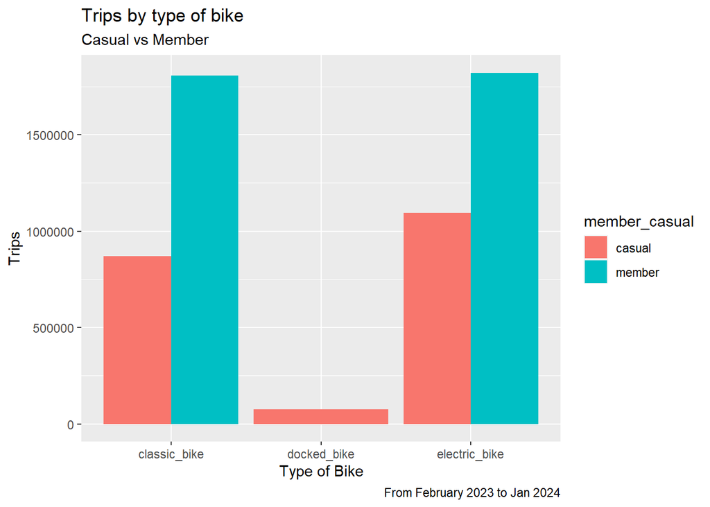

```r
complete_trips_2 %>%
  group_by(member_casual, rideable_type) %>%
  summarize(num_rides = n(),) %>%
  arrange(member_casual, rideable_type) %>%
  ggplot(aes(x=rideable_type, y= num_rides, fill=member_casual)) + geom_col(position="dodge") + xlab("Type of Bike") + ylab("Trips")+ scale_y_continuous(labels=function(x) format (x, scientific= FALSE))+ labs(title="Trips by type of bike", subtitle="Casual vs Member",caption="From February 2023 to Jan 2024")
```

#### Total number of trips by members

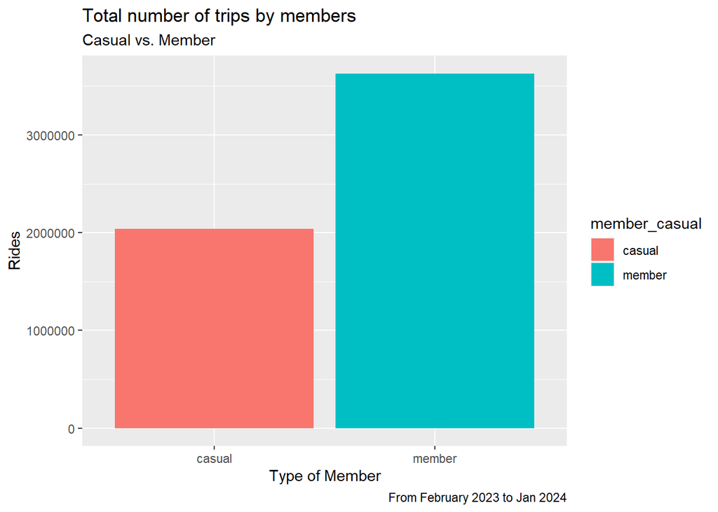

```r
ggplot(data=complete_trips_2) + geom_bar(aes(x=member_casual, fill = member_casual)) + labs(title="Total number of trips by members", subtitle =  "Casual vs. Member",caption="From February 2023 to Jan 2024") + xlab("Type of Member") + ylab("Rides") + scale_y_continuous(labels=function(x) format (x, scientific= FALSE))
```

#### Number of rides per member by day of the week

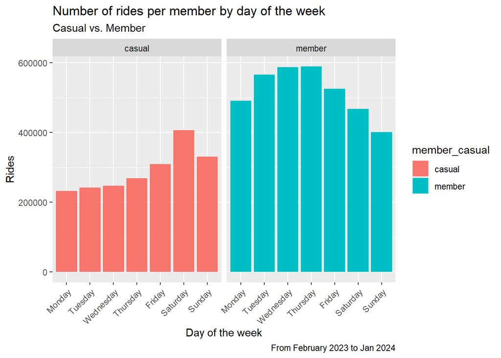

```r
ggplot(data=complete_trips_2)+ geom_bar(aes(x=day_of_week, fill=member_casual)) +facet_wrap(~member_casual)+theme(axis.text.x=element_text(angle=45, hjust=1,vjust=1))+ labs(title = "Number of rides per member by day of the week", subtitle = "Casual vs. Member",caption="From February 2023 to Jan 2024") + xlab("Day of the week") + ylab("Rides")+ scale_x_discrete(labels=c("Monday","Tuesday","Wednesday","Thursday","Friday","Saturday","Sunday")) + scale_y_continuous(labels=function(x) format (x, scientific= FALSE))
```

#### Average ride length by member per day of the week

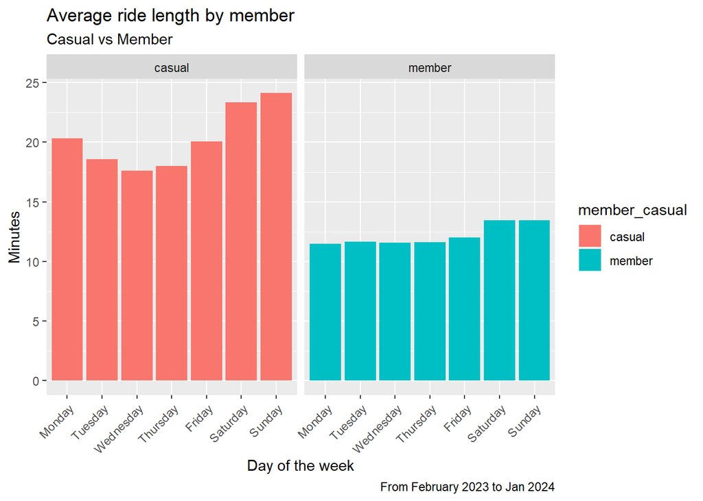

```r
complete_trips_2 %>%
  group_by(member_casual, day_of_week) %>%
  summarize(num_rides = n(), avrg_ride=mean(ride_length)) %>%
  arrange(member_casual, day_of_week) %>%
  ggplot(aes(x=day_of_week, y= avrg_ride, fill=member_casual)) + geom_col(position="dodge")+ facet_wrap(~member_casual) + xlab("Day of the week") + ylab("Minutes")+ scale_x_discrete(labels=c("Monday","Tuesday","Wednesday","Thursday","Friday","Saturday","Sunday")) + scale_y_continuous(labels=function(x) format (x, scientific= FALSE))+ theme(axis.text.x=element_text(angle=45, hjust=1,vjust=1))+ labs(title="Average ride length by member", subtitle="Casual vs Member",caption="From February 2023 to Jan 2024")
```

#### Rides per month

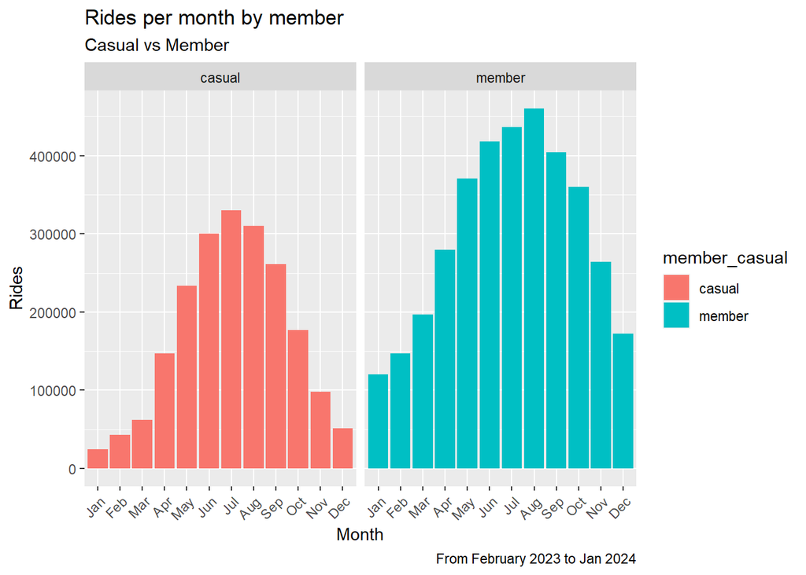

```r
complete_trips_2 %>%
  group_by(member_casual, month) %>%
  summarize(num_rides = n()) %>%
  arrange(member_casual, month) %>%
  ggplot(aes(x=month, y= num_rides, fill=member_casual)) + geom_col(position="dodge")+ facet_wrap(~member_casual) + xlab("Month") + ylab("Rides")+ scale_y_continuous(labels=function(x) format (x, scientific= FALSE))+ scale_x_discrete(labels=c("Jan","Feb","Mar","Apr","May","Jun","Jul","Aug","Sep","Oct","Nov","Dec"))+ theme(axis.text.x=element_text(angle=45, hjust=1,vjust=1))+ labs(title="Rides per month by member", subtitle="Casual vs Member", caption="From February 2023 to Jan 2024")
```

#### Average ride length per month

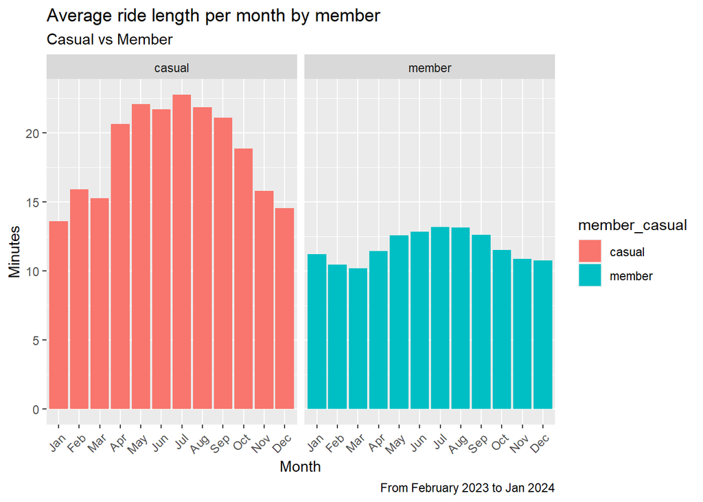

```r
complete_trips_2 %>%
  group_by(member_casual, month) %>%
  summarize(num_rides = n(), avrg_ride=mean(ride_length)) %>%
  arrange(member_casual, month) %>%
  ggplot(aes(x=month, y= avrg_ride, fill=member_casual)) + geom_col(position="dodge")+facet_wrap(~member_casual)+ xlab("Month") + ylab("Minutes")+ scale_y_continuous(labels=function(x) format (x, scientific= FALSE))+ scale_x_discrete(labels=c("Jan","Feb","Mar","Apr","May","Jun","Jul","Aug","Sep","Oct","Nov","Dec"))+ theme(axis.text.x=element_text(angle=45, hjust=1,vjust=1))+ labs(title="Average ride length per month by member", subtitle="Casual vs Member", caption="From February 2023 to Jan 2024")
```

### 6. Share

In order to share the analysis process with the stakeholders, a slide presentation will be made in *Google Slides*, the content of the presentation includes analysis process, graphs, key findings, and recommendations for the marketing team, the presentation is available in the next [link](https://docs.google.com/presentation/d/1ELokZ0qMRex9q-SjBJLLsEUfmeXO6k7mRr7g1JApHqk/edit#slide=id.p)

### 8. Act

#### Recommendations

1. *Make an attractive offer:* Show the *casual members* the exclusive benefits of becoming a *member* and how the price for a membership benefits the casual rider.
2. *Marketing strategies:* Create attractive content in social media like Instagram and Tik Tok. Also, take advantage of platforms like Google Ads or Facebook Ads to reach our desired audience. In addition, Cyclistic can host free public events to help the audience know the benefits of using the service of Cyclistic and its benefits.
3. *Make membership process easier:* Create a website that contains the information about the membership. Furthermore, the process the register yourself as a member has to simple an quick. As well, offer a variety of options to make the payment and make the *casual members* choose their best option according to their needs.
4. *Customer service:* Offer a responsive customer service, that answers all the communities questions. This service, will inform members about activities and the benefits that Cyclistic offers. Most important, we can create a community where all the members can interact with each other.
5. *Offer a free membership* to customers that are interested before they commit to pay.
6. *Offer discounts* to the customer who join Cyclistic with family and friends.